# Credit Card Approval Prediction

Final Group 7 - Members SID:500389793,500421956, 500138423, 500193673, 440428183, 500207796, 500297661

10/12/2020

### 1. Introduction

Evaluating a customer’s merit before issuing a credit card is a critical task for any financial institution. An applicant’s credit history and personal details are used to predict their credit eligibility. Machine Learning is pivotal for solving this problem, where data complexity and volume requires using complex methods to detect patterns and inferences from the data. Our objective is to predict the risk for a customer (risky/not risky) and not paying off his credit debt in time based on a range of features.

### 2. Dataset Description

The dataset https://www.kaggle.com/rikdifos/credit-card-approval-prediction is comprised of two tables: the application data and the credit history. The first table contains 18 columns of both **numerical and categorical data** of applicant’s personal details. The second table records the status of credit card payment for each applicant for each month. The two files are linked by ID. The joint IDs across the two tables are **36440** samples. Both DAYS_BIRTH and DAYS_EMPLOYED count backwards from current day (0), -1 means yesterday. If DAYS_EMPLOYED is positive, it means the person is currently unemployed. The MONTHS also counts backwards from The month of the extracted data.

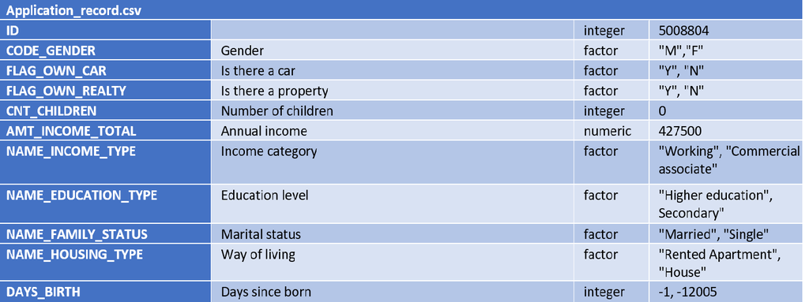

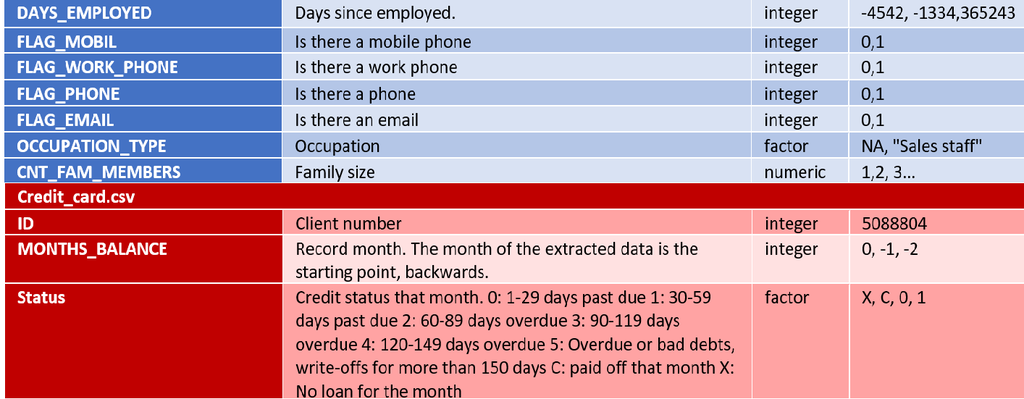

Table 1: Dataset Description

### 3. Methodology

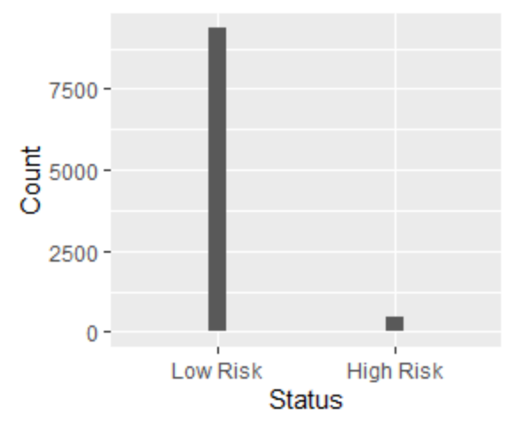

```r
#histogram
ggplot(data, aes(x= STATUS)) + geom_bar(width = 0.1) + scale_x_discrete(labels=c("Low Risk", "High Risk"))+labs(x="Status",y = "Count"
                                                                                                                #,title = paste0("Frequency Distribution of", "\n", "Status")
                                                                                                                )+theme(plot.title = element_text(hjust = 0.5))
```

The Credit history is grouped by ID and aggregated on the maximum STATUS given for a customer during his recorded months. The result is joined with the application data to form a single record per user. It is important to note that 47 IDs in the Application Data were repeated, with records not being true duplicates. These records were therefore deemed corrupt and dropped before merger. FLAG_MOBIL which states whether a customer has a mobile phone or not is all ones, so was dropped from the data. DAYS_BIRTH and DAYS_EMPLOYED are transformed into years by multiplying them to -1/365, and subsequently renamed into AGE and YEARS_EMPLOYED. After some analysis and research on the data, **we decided that the categories for late payment which are 60 days and above (>= 2) are to be labeled as risky, and otherwise non-risky. Using filled bar charts, grouped densities, as well as T-SNE for classes visualization, we chose to pursue a binary classification problem, seeing the high inseparability between between risk (2,3) and high risk (4,5) classes**. The resultant class distribution is shown.

### 4. Exploratory Data Analysis

#### 4.2 Outliers

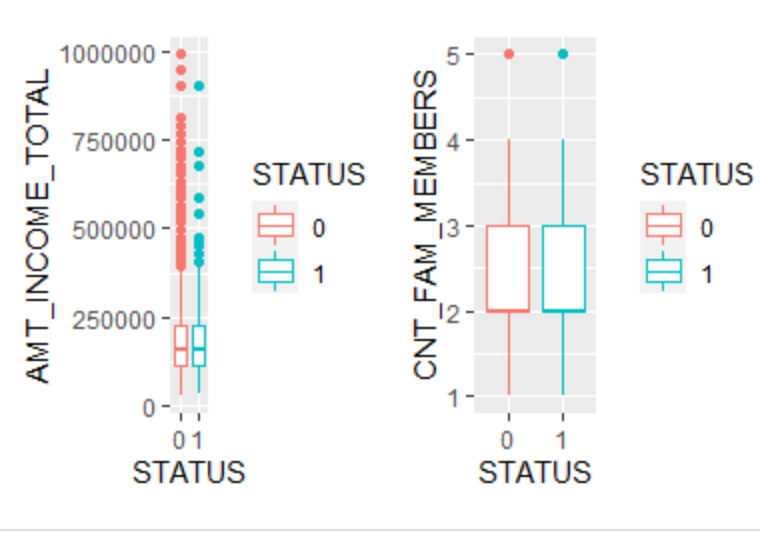

```r
#distribution of cont variables
g1 <- ggplot(data= data, aes(x= STATUS, y= AMT_INCOME_TOTAL)) + geom_boxplot(aes(color= STATUS))
g2 <- ggplot(data= data, aes(x= STATUS, y= CNT_FAM_MEMBERS)) + geom_boxplot(aes(color= STATUS))
grid.arrange(g1,g2,ncol= 2)
```

Family members above 5 and income above a million were considered outliers and subsequently discarded from the data set. Also there is little distinction when considering the class variable.

```r
ggplot(data= data, aes(x= AMT_INCOME_TOTAL, y= NAME_INCOME_TYPE, fill= NAME_INCOME_TYPE)) + geom_boxplot()
```

[output not shown]

```r
#manage outliers
data <- data %>% filter(CNT_FAM_MEMBERS <= 5)
data <- data %>% filter(AMT_INCOME_TOTAL < 1000000)
```

#### 4.3 Correlation

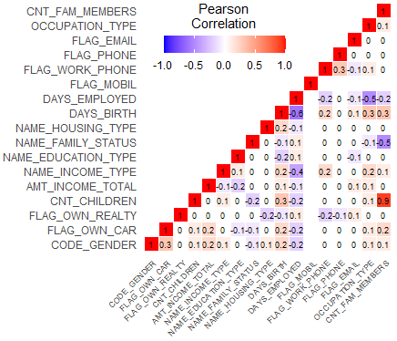

The correlation matrix provides some insights. Family Status is as expected correlated to the family members. **Count children is highly correlated to family members, which means this feature could be redundant. Count children is also expectedly correlated to age. Years employed also is correlated to the income type**. Years employed is also highly correlated to age. Most findings are intuitive, which gives credence to the data being reliable.

```r
df_application = read.csv(file = 'application_record.csv')
df_application <- df_application[ -c(1) ]

#df_application <- appl.data

cormat <- round(cor(data.matrix(df_application)),1)

# Get upper triangle of the correlation matrix
get_upper_tri <- function(cormat){
  cormat[lower.tri(cormat)]<- NA
  return(cormat)
}

upper_tri <- get_upper_tri(cormat)

melted_cormat <- melt(upper_tri, na.rm = TRUE)

# Heatmap
ggheatmap <- ggplot(melted_cormat, aes(Var2, Var1, fill = value))+
geom_tile(color = "white")+
scale_fill_gradient2(low = "blue", high = "red", mid = "white", midpoint = 0,
                     limit = c(-1,1), space = "Lab", name="Pearson\nCorrelation") +
theme_minimal()+ # minimal theme
theme(axis.text.x = element_text(angle = 45, vjust = 1, size = 7, hjust = 1))+
coord_fixed()

ggheatmap +
geom_text(aes(Var2, Var1, label = value), color = "black", size = 2.5) +
theme(
  axis.title.x = element_blank(),
  axis.title.y = element_blank(),
  panel.grid.major = element_blank(),
  panel.border = element_blank(),
  panel.background = element_blank(),
  axis.ticks = element_blank(),
  legend.justification = c(1, 0),
  legend.position = c(0.6, 0.7),
  legend.direction = "horizontal")+
  guides(fill = guide_colorbar(barwidth = 7, barheight = 1,
                title.position = "top", title.hjust = 0.5))
```

#### 4.4 Data Missingness

##### Looking at Occupations

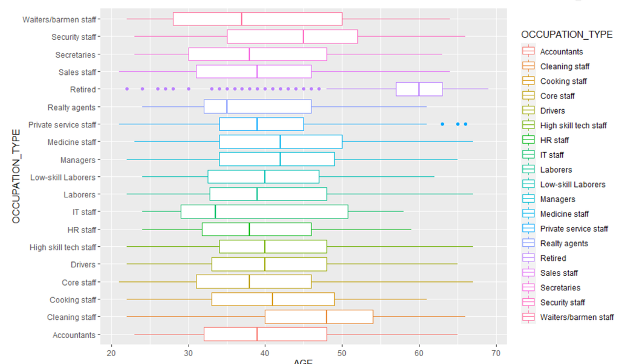

```r
ggplot(data = data, aes(y= OCCUPATION_TYPE, x= AGE, color= OCCUPATION_TYPE)) + geom_boxplot()
```

##### Looking at Negative Years Employed

[figure not shown]

```r
ggplot(data= data, aes(y= NAME_INCOME_TYPE, x= YEARS_EMPLOYED, fill= NAME_INCOME_TYPE)) + geom_bar(stat= "identity")
```

The Years Employed is made negative for the unemployed. Notice that happens with the Income Type= Pensioner. Pensioners constitute the majority of Occupation Type = NA, which justifies the seemingly high correlation between Years Employed being highly negative, matching an Occupation level of NA. We replaced NA Occupation that have an Income Type = “Pensioner”, with the level “Retired”.

##### Looking at Age and Years Employed

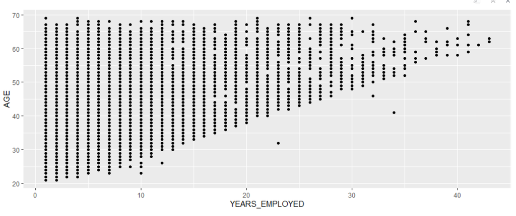

```r
ggplot(data= subset(data, YEARS_EMPLOYED > 0), aes(x= YEARS_EMPLOYED, y= AGE)) + geom_point()
```

For only the currently employed, strikingly, the Years Employed has a high variance with respect to Age, with many of older generation having years of experience less than a decade.

#### 4.5 Duplicates

```r
#drop ID
data <- data[, !colnames(data) %in% c("ID", "FLAG_MOBIL", "CNT_CHILDREN")]

#remove duplicates
duplicates <- which(duplicated(data))
data_before <- data
data <- data[-duplicates,]
```